# Final project

Prayag Gordy

5/4/2021

## 0.2 Data description

Table 1: Collection methods for data

| Data | Source | Link | Collection method |
| --- | --- | --- | --- |
| Infant mortality data | CDC WONDER | https://wonder.cdc.gov/controller/datarequest/D159 | Download |
| Demographic data | American Community Survey | https://www.census.gov/programs-surveys/acs | `tidycensus` package |

The data were collected as described in Table 1. Our outcome data will serve as our $y$ variables in regression, while our demographic data will serve as predictors. These demographic data will help show significant associations between indicators such as race and healthcare coverage with infant mortality.

## 0.3 Exploratory data analysis

Table 2: List of indicators collected

| Dataset | Indicator |
| --- | --- |
| Infant mortality data | Deaths |
|  | Births |
|  | Death rate |
| Demographic data | Total population |
|  | Population by sex |
|  | Population by age |
|  | Population by race |
|  | Median household income |
|  | Gini index of income inequality |
|  | Recipients of food stamps |
|  | Education levels |
|  | Health insurance coverage |

The indicators considered are listed in Table 2.

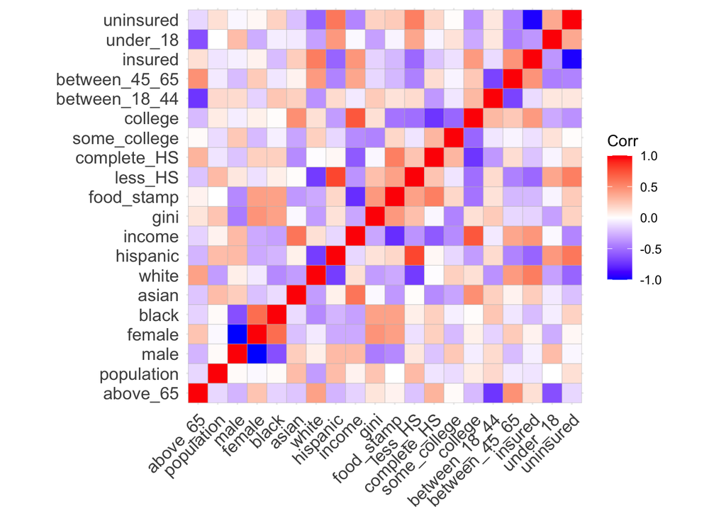

Figure 1: Correlation plot for indicators under consideration

In Figure 1 we can see the correlations between our different demographic indicators. There are some obvious correlations due to singularities, such as between male and female. There are important correlations to consider across types of indicators, such as insurance and income, race, and education; education and income and race; and food stamps and income. We can use interaction terms in the regression to account for this.

The graph below (Figure 2) shows the strong negative correlation between food stamps and income as an example of such an interaction.

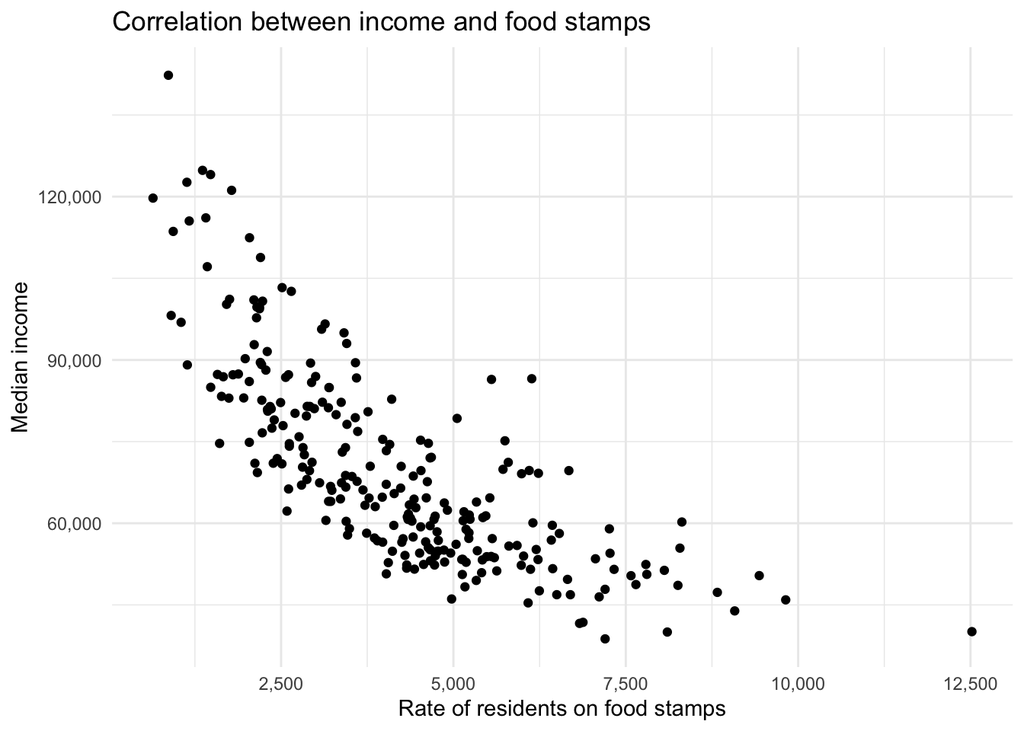

Figure 2: There is a strong negative correlation between food stamps and income

## 0.4 Data analysis

### 0.4.1 Variable selection

First, we set our models. The base model is of the form $y_i = \beta_0$. The full model looks like $y_i = \beta_0 + \beta_1x_{i,1} + \cdots + \beta_{17}x_{i,17}$. Finally, we also test a full model with interactions between insurance and income, race, and education; and income and education and race.

We can use forward stepwise selection to find the model with the lowest $\mathrm{AIC}$ score.

When comparing the full model to the base model, the best model is
$$\text{(death rate)} = \beta_0 + \beta_{1}\text{(income)} + \beta_{2}\text{(black)} + \beta_{3}\text{(hispanic)} + \beta_{4}\text{(male)} + \beta_{5}\text{(gini)} + \beta_{6}\text{(white)} + \beta_{7}\text{(asian)} + \beta_{8}\text{(some college)}$$

When comparing the model with interactions to the base model, the best model is
$$\text{(death rate)} = \beta_0 + \beta_{1}\text{(income)} + \beta_{2}\text{(black)} + \beta_{3}\text{(hispanic)} + \beta_{4}\text{(male)} + \beta_{5}\text{(gini)} + \beta_{6}\text{(white)} + \beta_{7}\text{(asian)} + \beta_{8}\text{(asian*income)} + \beta_{9}\text{(some college)} + \beta_{10}\text{(above 65)} + \beta_{11}\text{(college)} + \beta_{12}\text{(between 45 65)}$$

The $\mathrm{AIC}$ of the model with interactions is lower than that of the model without interactions, so we’ll use the one with interactions. Table 3 shows the summary table of this regression.

Table 3: Regression output for best model

|  | Estimate | CI (lower) | CI (upper) | Std. Error | t value | Pr(>\|t\|) |
| --- | --- | --- | --- | --- | --- | --- |
| (Intercept) | 17730.9969 | 1207.1078 | 34254.8860 | 8388.5481 | 2.1137 | 0.036 |
| income | -0.0659 | -0.0861 | -0.0456 | 0.0103 | -6.4098 | <0.001 |
| black | -0.0736 | -0.1520 | 0.0047 | 0.0398 | -1.8515 | 0.065 |
| hispanic | -0.1549 | -0.2299 | -0.0798 | 0.0381 | -4.0641 | <0.001 |
| male | 0.1873 | -0.0737 | 0.4483 | 0.1325 | 1.4135 | 0.159 |
| gini | -5449.6137 | -12151.5759 | 1252.3486 | 3402.3306 | -1.6017 | 0.111 |
| white | -0.1231 | -0.2019 | -0.0443 | 0.0400 | -3.0763 | 0.002 |
| asian | -0.2822 | -0.4308 | -0.1337 | 0.0754 | -3.7435 | <0.001 |
| some_college | -0.1274 | -0.2198 | -0.0351 | 0.0469 | -2.7176 | 0.007 |
| above_65 | -0.0790 | -0.1363 | -0.0216 | 0.0291 | -2.7135 | 0.007 |
| college | -0.0443 | -0.0919 | 0.0032 | 0.0241 | -1.8371 | 0.067 |
| between_45_65 | 0.0671 | -0.0259 | 0.1601 | 0.0472 | 1.4215 | 0.156 |
| income:asian | 0.0000 | 0.0000 | 0.0000 | 0.0000 | 3.0330 | 0.003 |

## 0.6 References

Table 1: Collection methods for data

| Data | Source | Link | Collection method |
| --- | --- | --- | --- |
| Infant mortality data | CDC WONDER | https://wonder.cdc.gov/controller/datarequest/D159 | Download |
| Demographic data | American Community Survey | https://www.census.gov/programs-surveys/acs | `tidycensus` package |